# Weekly 7: Who Visits the National Parks?

Author

Aiden Byrd

## Overview

In class, we started from a default chart and asked one question about every change: **what does this choice make the reader see?**

This week you’ll make those decisions yourself, on new data: visits to the U.S. National Parks, from the National Park Service, as collected for TidyTuesday. Kentucky has one of the parks in the data: Mammoth Cave.

The question: **Where does Mammoth Cave sit among the National Parks?**

This weekly is about **visualization judgment**. You’ll do a little cleaning to get there, but the point is the charts and your reasons for them.

A few things:

1. Add `#| echo: false` to your code blocks.
2. Use a new block when you move to a new task.
3. Code goes in the blocks. **Answers go outside them**, as prose. A comment inside a code chunk is not an answer.
4. Save the raw data to a file **once**, then work from the file. After it’s saved, add `#| eval: false` to the block that downloads it.
5. Every chart you hand in should use a colorblind-safe palette, if it uses color at all.

Due Monday, November 9 at 8pm.

# Part 1: Get the data, and know what you’re plotting

The data is here:

`https://raw.githubusercontent.com/rfordatascience/tidytuesday/master/data/2019/2019-09-17/national_parks.csv`

Read it in and save a copy to `data/raw/national_parks.csv`. Then read your saved copy and call it `parks_raw`.

```
Rows: 21,560
Columns: 12
$ year              <chr> "1904", "1941", "1961", "1935", "1982", "1919", "196…
$ gnis_id           <dbl> 1163670, 1531834, 2055170, 1530459, 277263, 578853, …
$ geometry          <chr> "POLYGON", "MULTIPOLYGON", "MULTIPOLYGON", "MULTIPOL…
$ metadata          <chr> NA, NA, NA, NA, NA, NA, NA, NA, NA, NA, NA, NA, NA, …
$ number_of_records <dbl> 1, 1, 1, 1, 1, 1, 1, 1, 1, 1, 1, 1, 1, 1, 1, 1, 1, 1…
$ parkname          <chr> "Crater Lake", "Lake Roosevelt", "Lewis and Clark", …
$ region            <chr> "PW", "PW", "PW", "PW", "PW", "NE", "IM", "NE", "IM"…
$ state             <chr> "OR", "WA", "WA", "WA", "CA", "ME", "TX", "MD", "TX"…
$ unit_code         <chr> "CRLA", "LARO", "LEWI", "OLYM", "SAMO", "ACAD", "AMI…
$ unit_name         <chr> "Crater Lake National Park", "Lake Roosevelt Nationa…
$ unit_type         <chr> "National Park", "National Recreation Area", "Nation…
$ visitors          <dbl> 1500, 0, 69000, 2200, 468144, 64000, 448000, 738700,…
```

> What type is `year`? Why isn’t it numeric?

> A character, it contains text values such as “total”

```
# A tibble: 114 × 2
   year      n
   <chr> <int>
 1 Total   386
 2 2016    379
 3 2015    375
 4 2013    373
 5 2014    373
 6 2011    370
 7 2012    370
 8 2010    366
 9 2007    363
10 2008    363
# ℹ 104 more rows
```

> Why would leaving the `Total` rows in create a problem for an analysis of annual visitation?

> The total rows combine visitation across multiple years, keeping them would cause us to double count.

> How many kinds of `unit_type` are there? For this assignment, keep only `National Park` records and annual observations. Call the result `np`, and make `year` a number.

> 30 different unit type groups

```
# A tibble: 30 × 2
   unit_type                                 n
   <chr>                                 <int>
 1 Ecological and Historic Preserve         26
 2 International Historic Site               5
 3 National Battlefield                    859
 4 National Battlefield Park               246
 5 National Battlefield Site                43
 6 National Historic Site                 3274
 7 National Historical Park               1984
 8 National Historical Park and Preserve    81
 9 National Lakeshore                      177
10 National Memorial                      1486
# ℹ 20 more rows
```

```
Rows: 4,682
Columns: 12
$ year              <int> 1904, 1935, 1919, 1944, 1948, 1931, 1940, 1971, 1936…
$ gnis_id           <dbl> 1163670, 1530459, 578853, 1377082, 293666, 1018241, …
$ geometry          <chr> "POLYGON", "MULTIPOLYGON", "MULTIPOLYGON", "POLYGON"…
$ metadata          <chr> NA, NA, NA, NA, NA, NA, NA, NA, NA, "http://nrdata.n…
$ number_of_records <dbl> 1, 1, 1, 1, 1, 1, 1, 1, 1, 1, 1, 1, 1, 1, 1, 1, 1, 1…
$ parkname          <chr> "Crater Lake", "Olympic", NA, NA, NA, NA, NA, NA, NA…
$ region            <chr> "PW", "PW", "NE", "IM", "SE", "SE", "MW", "PW", "NE"…
$ state             <chr> "OR", "WA", "ME", "TX", "FL", "NC", "MI", "CA", "VA"…
$ unit_code         <chr> "CRLA", "OLYM", "ACAD", "BIBE", "EVER", "GRSM", "ISR…
$ unit_name         <chr> "Crater Lake National Park", "Olympic National Park"…
$ unit_type         <chr> "National Park", "National Park", "National Park", "…
$ visitors          <dbl> 1500, 2200, 64000, 1409, 7482, 154000, 2962, 34500, …
```

> Before we visualize anything, check whether one row is one park in one year.

```
# A tibble: 95 × 3
   unit_code  year     n
   <chr>     <int> <int>
 1 DENA       1922     2
 2 DENA       1923     2
 3 DENA       1924     2
 4 DENA       1925     2
 5 DENA       1926     2
 6 DENA       1927     2
 7 DENA       1928     2
 8 DENA       1929     2
 9 DENA       1930     2
10 DENA       1931     2
# ℹ 85 more rows
```

You should find one park that appears twice in the same year. Here’s the cleaning decision for it; run this:

```r
np <- np |>
  distinct(unit_code, year, .keep_all = TRUE)
```

> After that cleaning, what does one row represent? How many parks are represented? What years does the file cover?

> One row represents one National Park in a specific year, there are 60 unique National Parks in the data set, years range from 1904-2016

```
# A tibble: 0 × 3
# ℹ 3 variables: unit_code <chr>, year <int>, n <int>
```

> Why does the ending year matter for the claims you make later?

> We do not want to assume the data goes all the way up to 2026 or anything.

# Part 2: Start with the obvious chart

Your audience wants to know how the National Parks compared in 2016.

```
# A tibble: 60 × 12
    year gnis_id geometry     metadata   number_of_records parkname region state
   <int>   <dbl> <chr>        <chr>                  <dbl> <chr>    <chr>  <chr>
 1  2016 1163670 POLYGON      <NA>                       1 Crater … PW     OR
 2  2016 1530459 MULTIPOLYGON <NA>                       1 Olympic  PW     WA
 3  2016  578853 MULTIPOLYGON <NA>                       1 <NA>     NE     ME
 4  2016 1377082 POLYGON      <NA>                       1 <NA>     IM     TX
 5  2016  293666 POLYGON      <NA>                       1 <NA>     SE     FL
 6  2016 1018241 MULTIPOLYGON <NA>                       1 <NA>     SE     NC
 7  2016 1616980 POLYGON      <NA>                       1 <NA>     MW     MI
 8  2016  277109 POLYGON      <NA>                       1 <NA>     PW     CA
 9  2016 1488805 MULTIPOLYGON <NA>                       1 <NA>     NE     VA
10  2016  203271 MULTIPOLYGON http://nr…                 1 Black C… IM     CO
# ℹ 50 more rows
# ℹ 4 more variables: unit_code <chr>, unit_name <chr>, unit_type <chr>,
#   visitors <dbl>
```

> Make the most obvious bar chart: park on the x-axis and 2016 visitors on the y-axis. Don’t improve it yet.

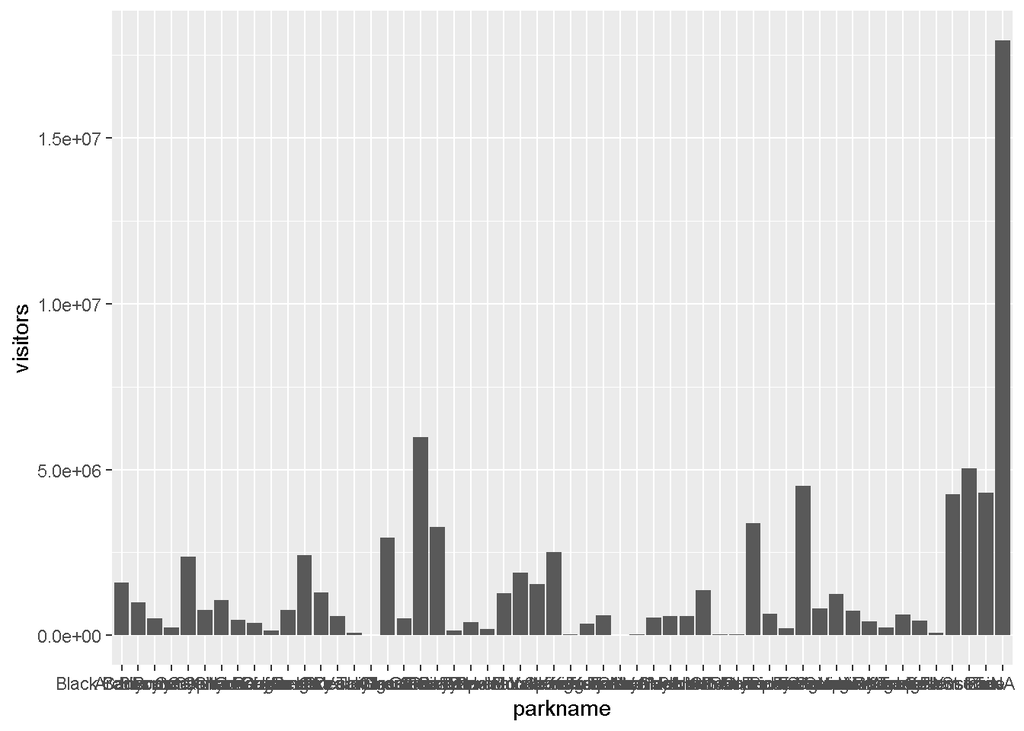

> Is the chart technically correct? What makes it difficult to use?

> It is correct because it shows the number of visitors for each National Park in 2016, however, it is very hard to read. The park names overlap on the x axis and the parks are not ordered by visitation.

# Part 3: Make the comparison readable

> Revise the chart so the park names are readable and the ordering helps the reader compare visitation.

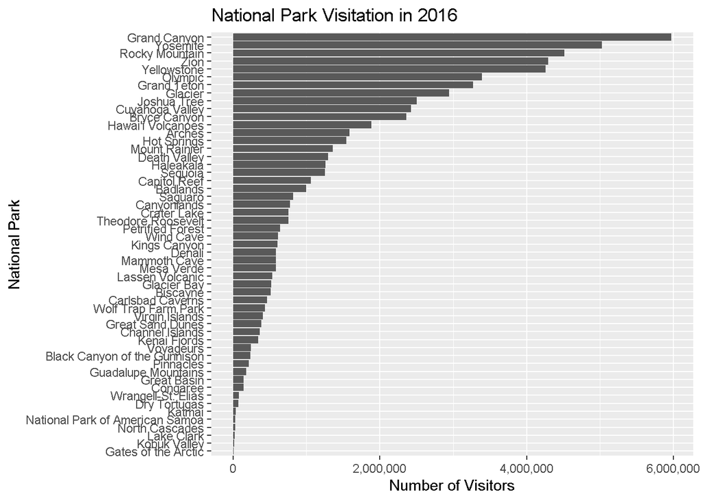

> Why put park names on the y-axis instead of the x-axis?

> Putting them on the Y axis makes it easier to read because they don’t overlap like they did on the X.

> Why reorder the parks by visitors?

> Reordering the parks by visitors makes it easier to compare them and see which parks have the most and least visitors

> Should every park get its own color?

> No I think that would make the chart too hard to understand

# Part 4: A real visualization problem

Mammoth Cave is the local park we care about. First, find where it ranks in 2016.

```
# A tibble: 1 × 3
  parkname     visitors  rank
  <chr>           <dbl> <int>
1 Mammoth Cave   586514    29
```

Now the design problem:

> A chart of only the top 10 parks makes Mammoth Cave disappear. A chart with 60 equally emphasized parks makes the reader work too hard. Create one visualization that helps a reader understand where Mammoth Cave sits relative to the other National Parks.

There is no one right chart here. Make the one you can defend.

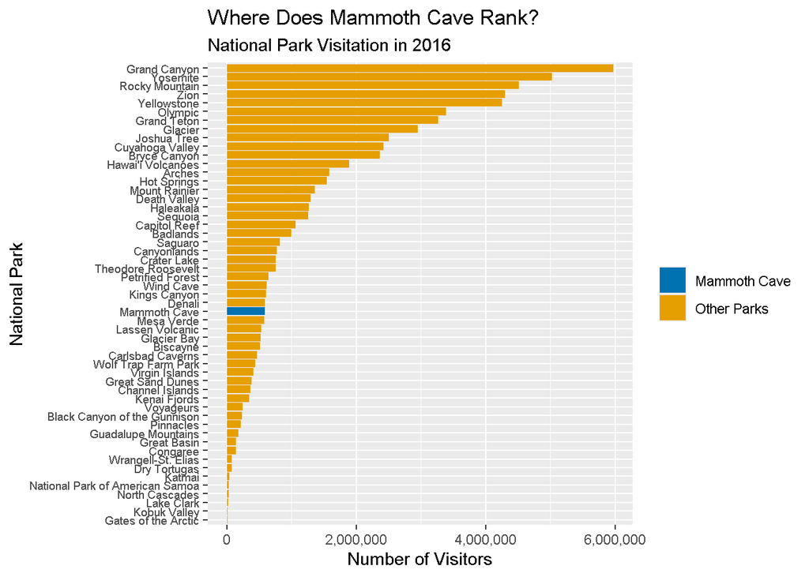

# Part 5: Defend the choices

> What should the reader notice first when they look at your final chart?

> They should notice the highlighted Mammoth Cave in blue and how it ranks compared to other national parks.

> Name two visualization choices you made deliberately. For each one, explain what that choice helps the reader see.

> I used horizontal bars so the names would be easier to read instead of overlapping on the X axis, I also used different colors to highlight Mammoth Cave and make it stand out.

> Name one visualization choice you considered but rejected. Why did you reject it?

> I considered using a vertical bar chart but decided against it because the park names would overlap and be difficult to read on the X axis.

> What does your chart support saying? What does it **not** support saying?

# Bringing it together

> In 3–4 sentences, answer the question for your reader: where does Mammoth Cave sit among the National Parks? Include one number, one interpretation, and one limitation.

# Disclosure appendix

> What did you try first? Include the code you wrote and the actual error message, or a clear description of the problem if there was no error.

> No actual coding errors, but couldn’t get the csv file to save in the right folder or place for a while. I had to get my path and all that with getwd and file.exists

> If you used an AI system: the exact prompt, exactly what it returned, what it got wrong or left unclear, and what you changed.

> If you didn’t use one, say so. I did not

# Before you submit

Render in a clean session: restart R, then render. Commit and push the `.qmd`, the `.html`, **and** your saved `.csv`.